# Classification by Logistic Regression

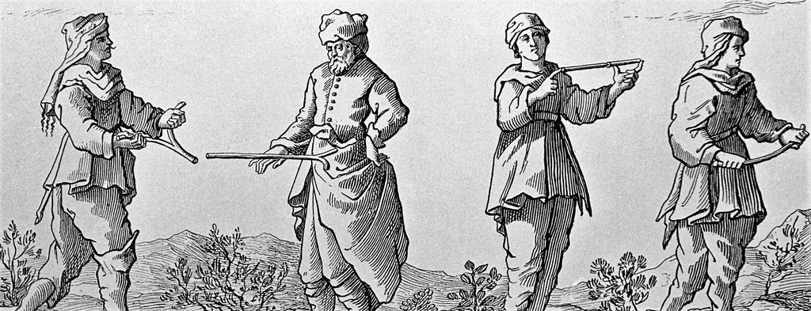

== document setup ==

## Synopsis

The logistic regression method is used to build a classification model. The form of the model is a set of coefficients of a vector sigmoid function.

Method:  
Treat class values as numeric (0 or 1). Find the vector sigmoid function that best approximates the data. Use this function as a measure of the probability of being in a certain class.

$$ P(class=B) = \frac{1}{1 + e^{\, - \, \large {(\beta_0 + \beta_1x_1 + \beta_2x_2 + ...)}}} $$

**Terms**

- Sigmoid function or logistic function

## Exposition

### Logistic Regression with One Predictor Variable

#### Sigmoid Functions

A sigmoid function rescales any numeric value into range 0 to 1.

$$sigmoid_{\beta_0\beta_1}(x) = \frac{1}{1 + e^{\, - \, \large {(\beta_0 + \beta_1x_1)}}} $$

range: $0 < sigmoid_{\beta_0\beta_1}(x) < 1$, for any $x$

#### Data

Consider these data and new observation.

**data**

| x1 | class |
| --- | --- |
| -9 | A |
| -5 | A |
| -1 | B |
| 0 | A |
| 3 | B |
| 5 | B |
| 9 | B |

**new**

| x1 |
| --- |
| 1 |

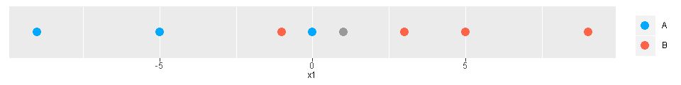

#### Convert Class Variable from Categorical to Binary

**data (transformed)**

| x1 | class | class.bin |
| --- | --- | --- |
| -9 | A | 0 |
| -5 | A | 0 |
| -1 | B | 1 |
| 0 | A | 0 |
| 3 | B | 1 |
| 5 | B | 1 |
| 9 | B | 1 |

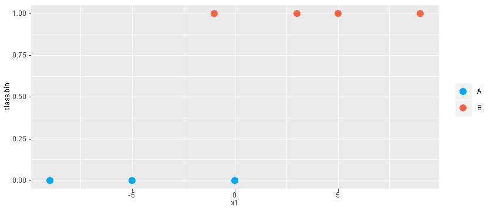

#### Assume Sigmoid Function Approximates the Underlying Process

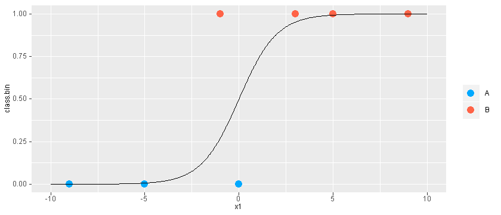

#### Optimize Sigmoid Function to Best Fit the Existing Data

**model**

| b0 | b1 |
| --- | --- |
| 0.444605 | 0.7040943 |

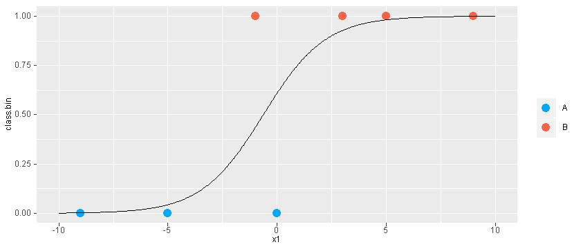

#### Prediction

The new observation's class is predicted to be B because sigmoid(1) = 0.76 > 0.50, assuming a cutoff of 0.50.

**new**

| x1 | 1-sigmoid=prob.A | sigmoid=prob.B | class.predicted |
| --- | --- | --- | --- |
| 1 | 0.2407267 | 0.7592733 | B |

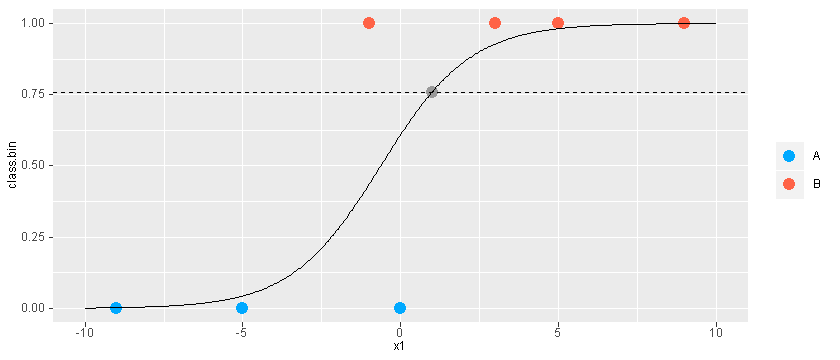

### Logistic Regression with Many Predictor Variables

#### Vector Sigmoid Functions

A vector sigmoid function rescales any vector of numeric values into range 0 to 1.

$$sigmoid_{\beta_0\beta_1\beta_2...} = \frac{1}{1 + e^{\, - \, \large {(\beta_0 + \beta_1x_1 + \beta_2x_2 + ...)}}} $$

range: $0 < sigmoid_{\beta_0\beta_1\beta_2...}(x1, x2, ...) < 1$, for any $x1, x2, ...$

#### Data

Consider these data and new observations.

**data**

| x1 | x2 | x3 | class |
| --- | --- | --- | --- |
| 4 | 9 | 9 | A |
| 2 | 7 | 8 | B |
| 3 | 6 | 2 | A |
| 2 | 5 | 2 | B |
| 5 | 4 | 3 | A |
| 1 | 8 | 3 | B |
| 7 | 2 | 4 | A |
| 8 | 1 | 4 | B |

**new**

| x1 | x2 | x3 |
| --- | --- | --- |
| 5 | 8 | 1 |
| 6 | 7 | 5 |
| 4 | 6 | 2 |
| 1 | 1 | 6 |

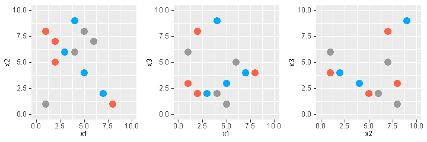

#### Model

**model**

| b0 | b1 | b2 | b3 |
| --- | --- | --- | --- |
| 88.58359 | -11.88038 | -10.9658 | 4.248673 |

#### Prediction

The new observations' classes are predicted like this, assuming a cutoff of 0.50.

| x1 | x2 | x3 | 1-sigmoid=prob.A | sigmoid=prob.B | class.predicted |
| --- | --- | --- | --- | --- | --- |
| 5 | 8 | 1 | 1.000000e+00 | 2.220446e-16 | A |
| 6 | 7 | 5 | 1.000000e+00 | 2.220446e-16 | A |
| 4 | 6 | 2 | 9.999999e-01 | 8.893374e-08 | A |
| 1 | 1 | 6 | 2.220446e-16 | 1.000000e+00 | B |

Copyright (c) Berkeley Data Analytics Group, LLC Document revised September 22, 2019